# Timeseries HW1

Chaewon Kim(2015122043)

2019/ 04/ 12

## 과제 개요

- 계절지수평활법의 정의와 내용
- 데이터 설명
- 시도표
- 계절지수평활법
  - 가법 모형
  - 승법 모형
- 최종 모형

## Winters의 계절지수평활법

### 가법계절모형 (Additive seasonal model)

: 시계열의 평균수준이 시간의 흐름에 따라 변화하지만 그 변동의 폭, 즉, 분산이 시간의 흐름에 관계없이 일정한 경우(homogeneous)

$$Z_{n+l}=T_{n+l}+S_{n+l}+I_{n+l}$$

- T : 추세요인
- S : 계절주기 s를 가지는 계절요인
- I : 오차항으로서 불규칙 요인

### 승법계절모형 (multiplicative seasonal model)

: 분산이 시간의 흐름에 따라 점차로 커지는 경우

$$Z_{n+l}=T_{n+l}*S_{n+l}+I_{n+l}=(T_n+\beta_{1,n})S_{n+l}+I_{n+l}$$

- T : 추세요인
- S : 계절주기 s를 가지는 계절요인
- I : 오차항으로서 불규칙 요인

## 데이터

| 정보 | 내용 |
| --- | --- |
| 데이터 명 | BOK_energy_oil.csv |
| 데이터 종류 | csv file, data frame |
| 변수 개수 | 1개 |
| 변수 정보 | 기름값 |
| 관측치 개수 | 267개 |
| 관측치 정보 | 시간에 따른 기름값 |

## 시도표 확인하기

데이터를 불러온 후 ts함수를 이용해 시계열 데이터로 변환해준다.

데이터에 대한 사전정보가 없으므로 1996년 1월부터 2018년 3월까지 매달 기름값(단위생략)이라고 임의로 지정해주었다.

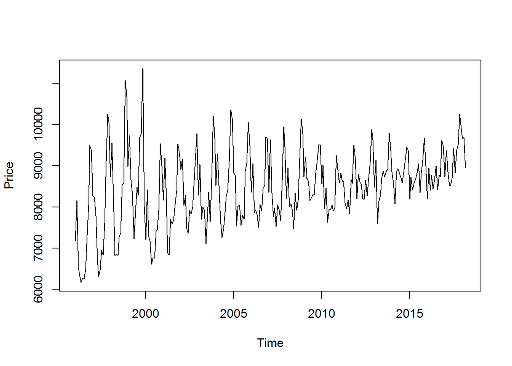

```r
library('forecast')
setwd("C:\\Users\\cwjen_000\\Desktop\\ds_yonsei")
oil<- read.csv("BOK_energy_oil.csv", header=T)
oil <-ts(oil, start=c(1996,1), end=c(2018,3), frequency=12)
plot.ts(oil, xlab="Time", ylab="Price")
```

**시도표를 보니 계절성과 추세가 둘 다 보인다. 시간이 갈수록 증가하는 추세를 보이며, 변동의 폭이 시간이 갈수록 조금씩 작아진다.**

## 계절지수평활법 사용하기

*-forecast패키지 사용*

### **승법모형**

```r
fit1 <- hw(oil, seasonal="multiplicative", h=10)
fit1$model
```

```
## Holt-Winters' multiplicative method
##
## Call:
##  hw(y = oil, h = 10, seasonal = "multiplicative")
##
##   Smoothing parameters:
##     alpha = 0.4217
##     beta  = 0.007
##     gamma = 0.3211
##
##   Initial states:
##     l = 7496.6324
##     b = 58.8229
##     s = 1.1744 1.231 1.0461 0.9642 0.872 0.8841
##            0.8644 0.8495 0.9135 1.0014 1.1453 1.0542
##
##   sigma:  0.0517
##
##      AIC     AICc      BIC
## 4755.473 4757.931 4816.457
```

R이 지정해준 승법모형의 알파, 베타, 감마의 값은 다음과 같다.

```r
alpha = 0.4217
beta  = 0.007
gamma = 0.3211
```

[output not shown]

### **가법모형**

```r
fit2 <- hw(oil, seasonal="additive", h=10)
fit2$model
```

```
## Holt-Winters' additive method
##
## Call:
##  hw(y = oil, h = 10, seasonal = "additive")
##
##   Smoothing parameters:
##     alpha = 0.7433
##     beta  = 0.0051
##     gamma = 1e-04
##
##   Initial states:
##     l = 7542.9428
##     b = 58.9811
##     s = 999.6203 1427.501 331.886 -84.6173 -501.6244 -414.1678
##            -720.4133 -738.1372 -468.4828 -336.6108 539.1375 -34.0907
##
##   sigma:  444.7876
##
##      AIC     AICc      BIC
## 4765.413 4767.871 4826.396
```

R이 지정해준 가법모형의 알파, 베타, 감마의 값은 다음과 같다.

```r
alpha = 0.7433
beta  = 0.0051
gamma = 1e-04
```

[output not shown]

## 최종 모형 선택

데이터와 가법모형, 승법모형은 다음과 같다.

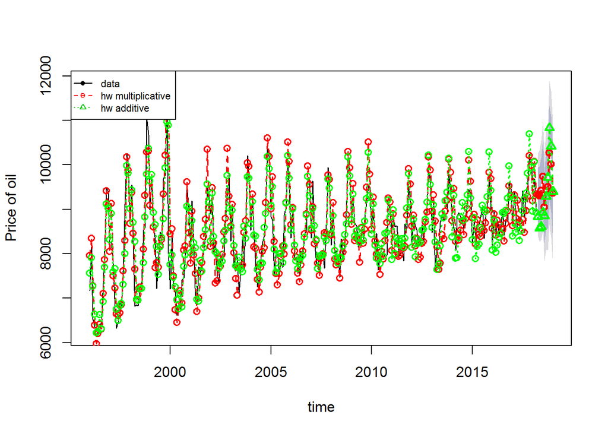